# Missing Immigrants

Team Migraine  
• Hazal Ünal  
• Zeynep Berna İnce  
MAT 381E Introduction to Data Science Term Project

26/06/2021

**Immigrants Problem in the World**

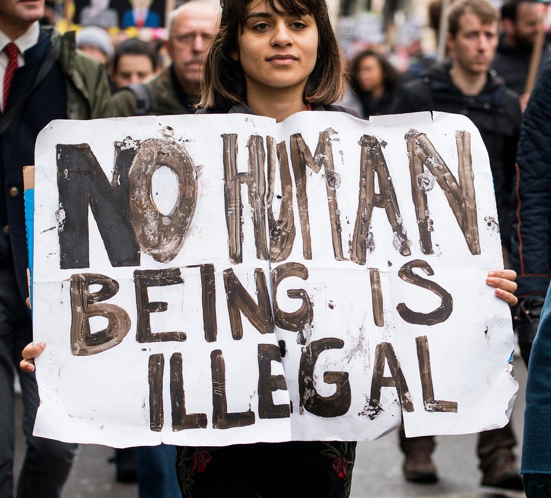

- **Project goal & social problem addressed:**

  Immigrants struggle many issues since the begining of their life until they found a better place to live in safety and peace. Since human beings are not in a position to choose where they were born, some may have experienced migration due to poor living conditions in their homeland. As a part of this project, we will analyze the migration process of those suffering from poverty. The data shows people who are lost, sick, and even died in this process and the primary goal of this project is to show missing immigrants’ gender, region, cause of deaths, life expectancy by years with data visualization.
- **Project data & access to data:**

  We used [International Organization for Migration (IOM)’s Missing Immigrants Project’s](https://missingmigrants.iom.int/downloads) data sets of 3 years.

**Gender Distribution of Immigrants**

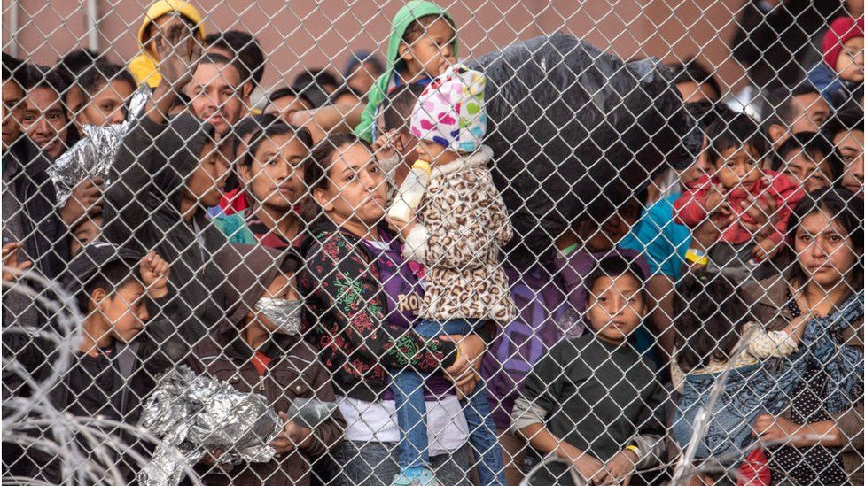

Since we all know the struggle of migration, it is not hard to imagine how hard it is to children. The things they witnessed during the migration are more traumatic and leave a mark in their life. Therefore, we wanted to highlight the of number children, female and male immigrants.

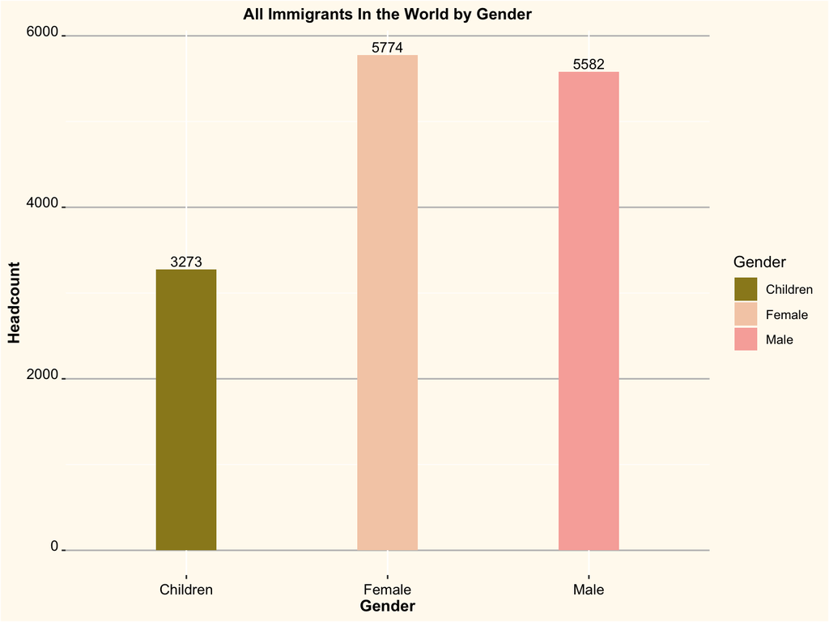

**Pie Chart of The Number of Dead and Survivors Immigrants**

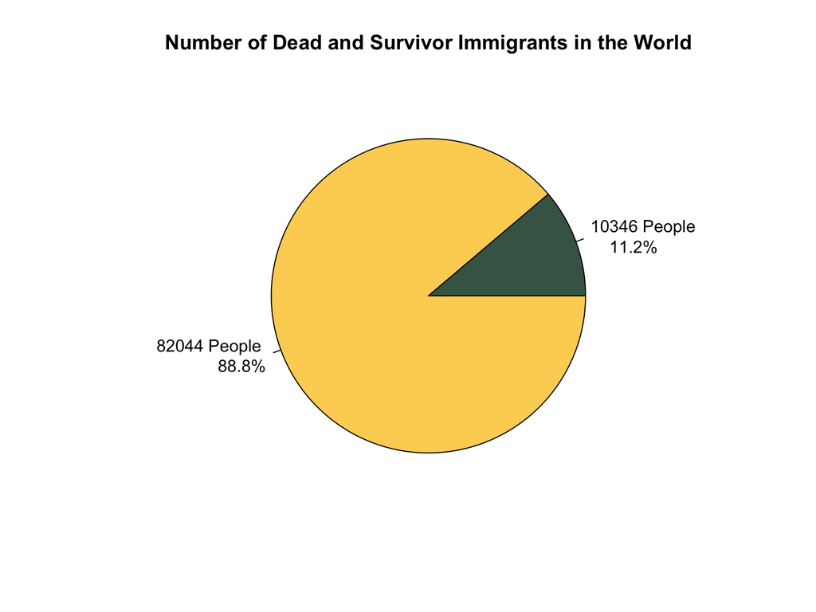

This is a pie chart that shows the total number of survivors and the total number of deaths and missing migrants over the three years we examined at our project. The data we analyzed shows that although 90% of immigrants survived, 10% of the unfortunate immigrants were recorded as dead or missing.

**Heat Map of The Number of Survivors Immigrants vs Total Dead and Missing Immigrants**

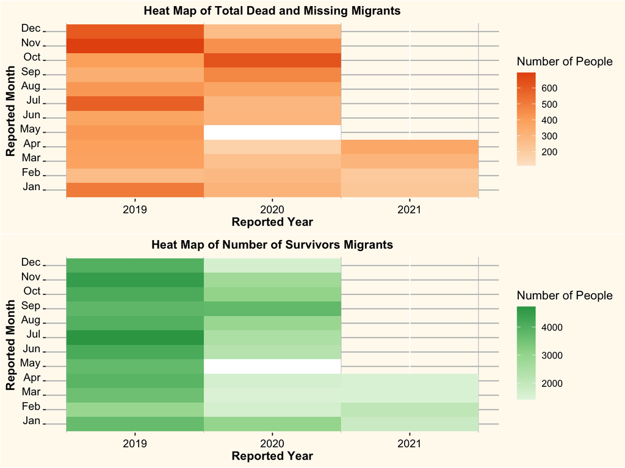

As we observed in the previous pie chart, there is a quiet difference between total dead and survivors. In this graph, we chose to use a heat map in order to determine these data monthly and yearly in the best way.

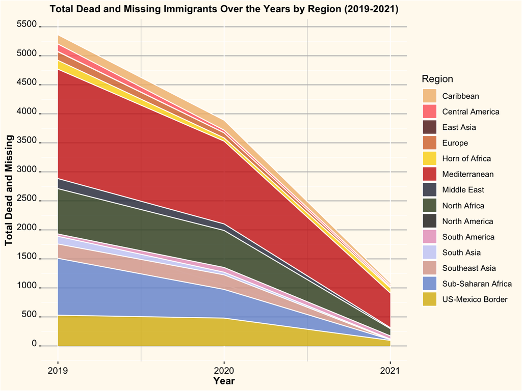

**Bar Chart of The Total Missing by Region and Year**

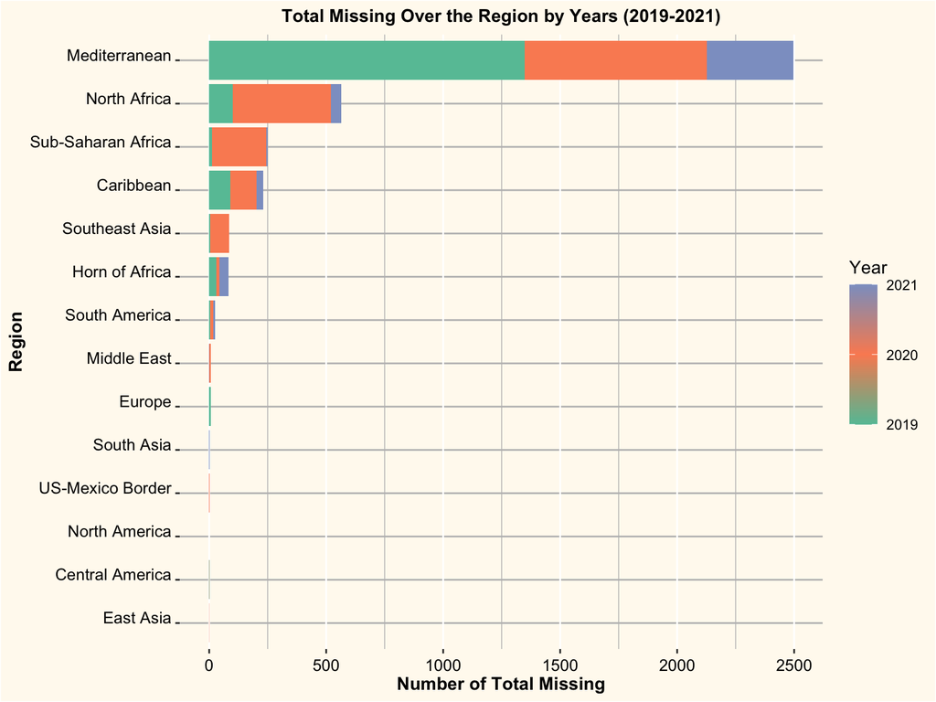

We already analyzed the total death and missing data jointly. In order to know the density of missing migrants in our project, we found the difference in the data on the total number of deaths we have. So we did get missing data on immigrants. We got that information on a regional basis and on a year-by-year basis. What is clear from this chart is that there are far too many missing migrants in the Mediterranean.

**Life Expectancy of Immigrants**

[figure not shown]

All those struggles affect the main problem: life expectancy. Lower life expectancy causes migration but migration does not guarantee 100 % living. The struggles experienced during migration and bad behavior of receiving country decrease the life expectancy rate. We obtained this data by dividing the number of survivors to total number immigrant by regions.

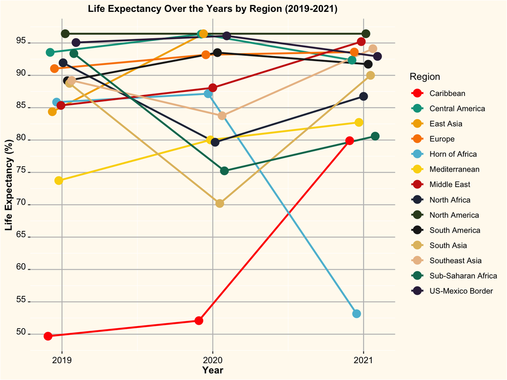

Line graph shows us life expectancy of immigrants is at least 50 %. In South Asia there is a huge decrease between 2019-2020 and a huge increase between 2020-2021. In general, life expectancy rate of the immigrants is higher than 80. Even though these numbers are very low for an ordinary people in the world, this outcome makes us think that the biggest problem here is missing immigrants.

**Treemap of The Most Popular Causes of Immigrant Deaths in the World**

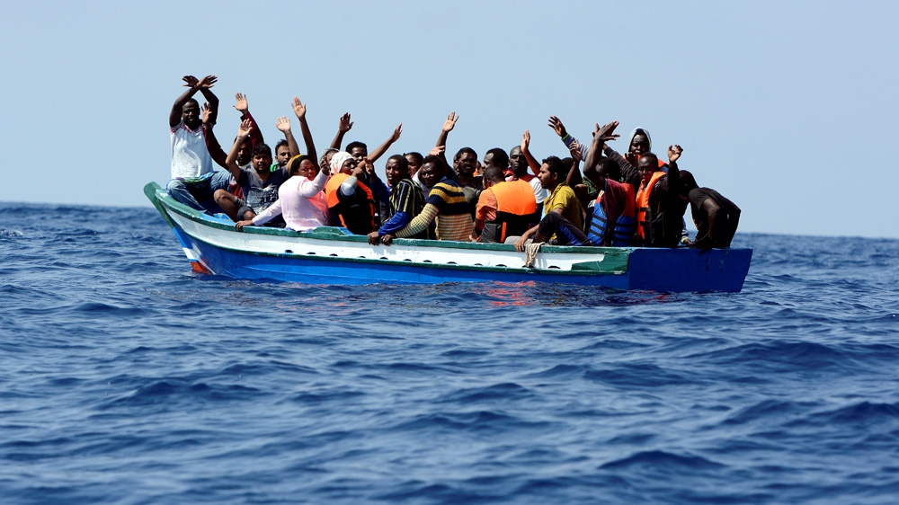

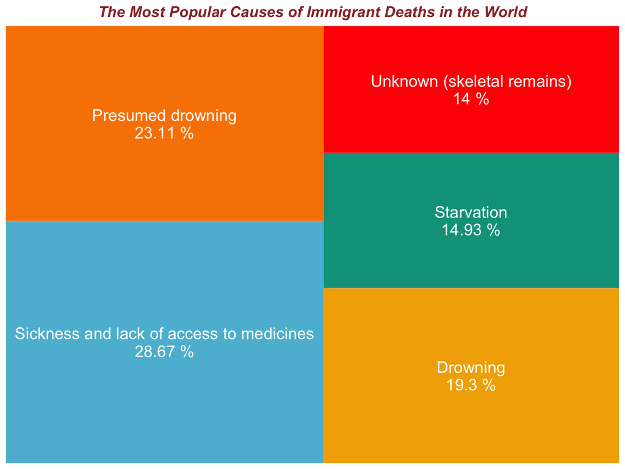

**Road to New Home**

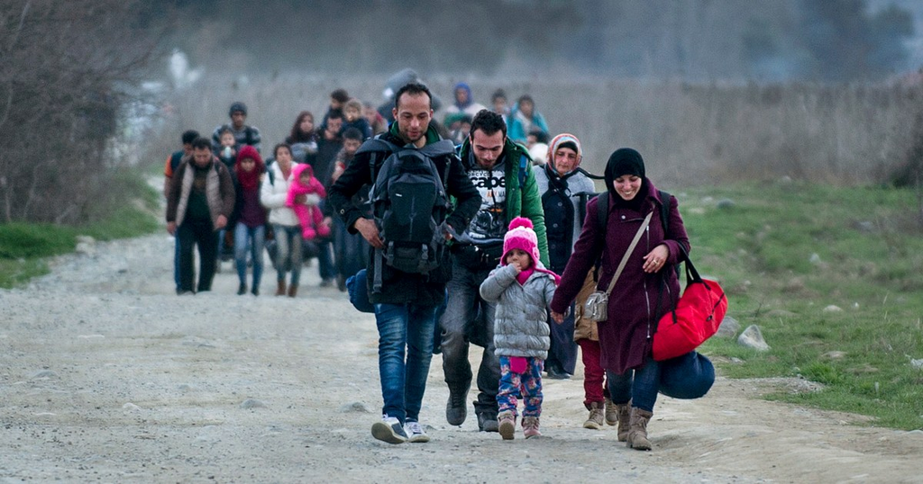

In hopes of reaching their new home at the end of the road, they try different routes.

[interactive chart not shown]

Here’s an interactive word cloud for the migration routes. Eastern Mediterranean and Western Balkans routes have almost same frequency. Especially Eastern Mediterranean supports the number of dead and missing immigrants data we showed above. It’s the second frequent route for migration. Thus, it has the most dead and missing immigrants. By combining these results, we may say that Mediterranean is not a safe place for immigrants. Mediterranean people’s stance on immigrants seems not too good.

**References**

-https://missingmigrants.iom.int/downloads

-https://shiny.rstudio.com

-https://github.com/karthik/wesanderson

-https://www.r-graph-gallery.com/ggplot2-package.html

-https://www.displayr.com/how-to-make-an-area-chart-in-r/